# Matplotlib, a base dos gráficos em python

## 📌 Introdução ao Matplotlib

`matplotlib` é uma biblioteca fundamental para visualização de dados em Python. A interface mais comum é o `pyplot`, que permite criar gráficos de maneira simples e rápida.

## 📚 Instalação ou Importação da Biblioteca

No caso do Colab, o Matplolib já está instalado.

> Não sabe se está instalado ou não? Use o comando pip freeze no prompt de comando. Use pip install -U matplotlib no prompt para atualizar para a versão mais recente.

Em todo caso, mesmo previamente instalado, o primeiro passo é importar essa biblioteca para que possamos utilizar os recursos dela.

> Outro ponto importante é que sempre que você visualizar uma biblioteca sendo importada e depois o comando as, isso cria um apelido para depois poder chamar recursos dessa biblioteca.

```python
import matplotlib.pyplot as plt
import pandas as pd
import numpy as np
```

> Aqui você tem acesso a documentação da bibloteca: https://matplotlib.org/stable/api/_as_gen/matplotlib.pyplot.axes.html

## 🧱 Passos para Criar um Gráfico

1. Criar os dados
2. Criar a figura e os eixos com `plt.subplots()`
3. Traçar os dados com `ax.plot()` ou equivalente
4. Adicionar personalização como títulos
5. Exibir com `plt.show()`

```python
import pandas as pd
```

```python
# Criar os dados

df = pd.DataFrame({
    "X": [10, 15, 20, 25, 30, 35, 40],
    "Y": [20, 24, 28, 32, 36, 40, 44]
})
```

```python
df
```

|  | X | Y |
| --- | --- | --- |
| 0 | 10 | 20 |
| 1 | 15 | 24 |
| 2 | 20 | 28 |
| 3 | 25 | 32 |
| 4 | 30 | 36 |
| 5 | 35 | 40 |
| 6 | 40 | 44 |

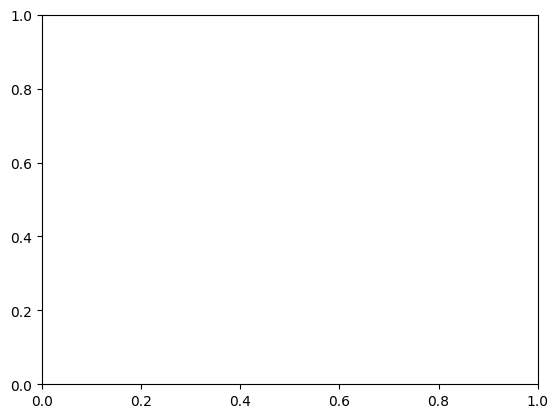

```python
# Criar a figura e os eixos com `plt.subplots()`

fig, ax = plt.subplots()
plt.show()
```

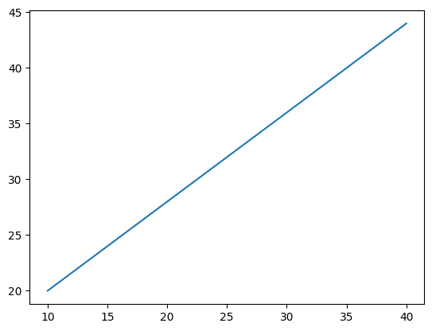

```python
# Traçar os dados com `ax.plot()` ou equivalente

fig,ax = plt.subplots()
ax.plot(df["X"], df["Y"])
plt.show()
```

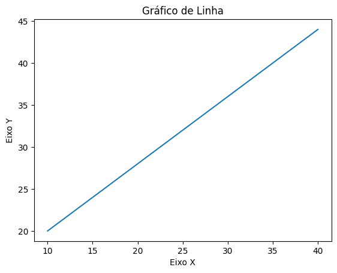

```python
# Adicionar personalização como títulos

fig, ax = plt.subplots()
ax.plot(df["X"], df["Y"])
ax.set_title('Gráfico de Linha')
ax.set_xlabel('Eixo X')
ax.set_ylabel('Eixo Y')
plt.show()
```

## 📊 Tipos de gráfico mais comuns

### 📊 Gráfico de Linha (plot)

Mostra a relação entre variáveis contínuas ao longo de um eixo (normalmente o tempo).

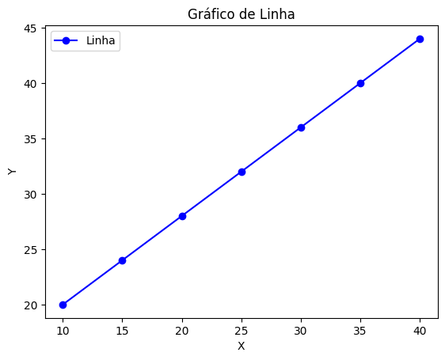

```python
fig, ax = plt.subplots()

plt.plot(df["X"], df["Y"], marker='o', color='blue', label='Linha')
plt.title("Gráfico de Linha")
plt.xlabel("X")
plt.ylabel("Y")
plt.legend()

plt.show()
```

### 📊 Gráfico de Dispersão (scatter)

Mostra a relação entre duas variáveis numéricas com pontos independentes.

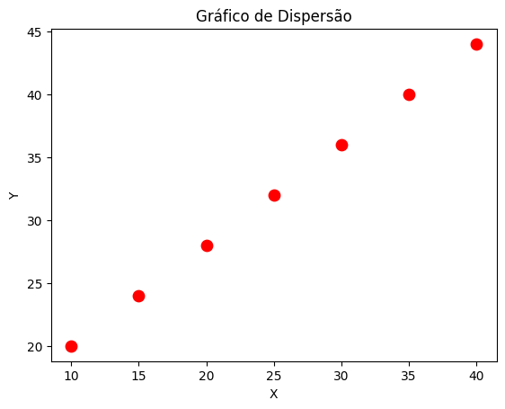

```python
fig, ax = plt.subplots()

plt.scatter(df["X"], df["Y"], color='red', s=80)
plt.title("Gráfico de Dispersão")
plt.xlabel("X")
plt.ylabel("Y")
plt.show()
```

### 📊 Gráfico de Barras (bar)

Compara valores entre categorias.

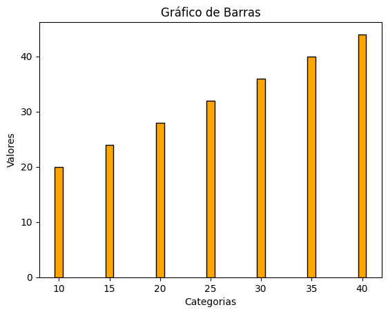

```python
plt.bar(df["X"], df["Y"], color='orange', edgecolor='black')
plt.title("Gráfico de Barras")
plt.xlabel("Categorias")
plt.ylabel("Valores")
plt.show()
```

### 📊 Gráfico de Barras Horizontais (barh)

Igual ao de barras, mas com orientação horizontal.

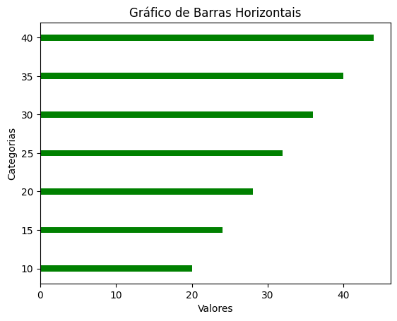

```python
plt.barh(df["X"], df["Y"], color='green')
plt.title("Gráfico de Barras Horizontais")
plt.xlabel("Valores")
plt.ylabel("Categorias")
plt.show()
```

### 📊 Gráfico de Pizza

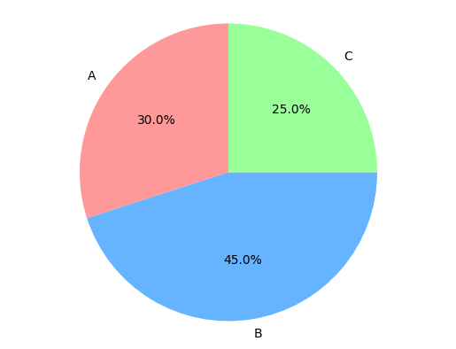

```python
labels = ['A', 'B', 'C']
sizes = [30, 45, 25]
colors = ['#ff9999','#66b3ff','#99ff99']

plt.pie(sizes, labels=labels, colors=colors, autopct='%1.1f%%', startangle=90)
plt.axis('equal')  # deixa circular
plt.show()
```

## 🎨 Personalização detalhada do Gráfico

### 📏 Título Principal

- **Função**: Define o título principal do gráfico
- **Código:** set_title()
- **Principais parâmetros**:
  - label (posicional) → texto do título.
  - fontsize → tamanho da fonte.
  - fontweight → peso da fonte ('normal', 'bold', etc.).
  - loc → alinhamento do título ('center', 'left', 'right').
  - pad → espaçamento do título.

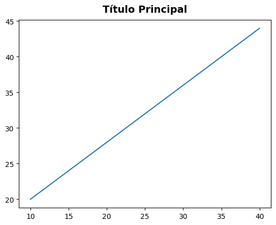

```python
# Exemplo de implementação

#Criação da figura
fig, ax = plt.subplots()

#Plotagem dos dados
ax.plot(df["X"], df["Y"])

#Personalização do título
ax.set_title("Título Principal",
             fontsize=14,
             fontweight='bold',
             loc='center',
             pad=10)

#Plotagem
plt.show()
```

### 📏 Título do Eixo X

- **Função**: Define o rótulo do eixo X (horizontal)
- **Código**: set_xlabel()
- **Principais parâmetros**:
  - xlabel (posicional) → texto do rótulo.
  - fontsize → tamanho da fonte.
  - labelpad → espaçamento entre o texto e o eixo.

[figure not shown]

```python
# Exemplo de implementação

fig, ax = plt.subplots()
ax.plot(df["X"], df["Y"])
ax.set_title("Título Principal", fontsize=14, fontweight='bold', loc='center', pad=30)
ax.set_xlabel("Eixo X", fontsize=12, pad=10)
plt.show()
```

### 📏 Título do Eixo Y

- **Função**: Define o rótulo do eixo Y (vertical).
- **Código:** set_ylabel()
- **Principais parâmetros**:
  - ylabel (posicional) → texto do rótulo.
  - fontsize → tamanho da fonte.
  - labelpad → espaçamento entre o texto e o eixo.

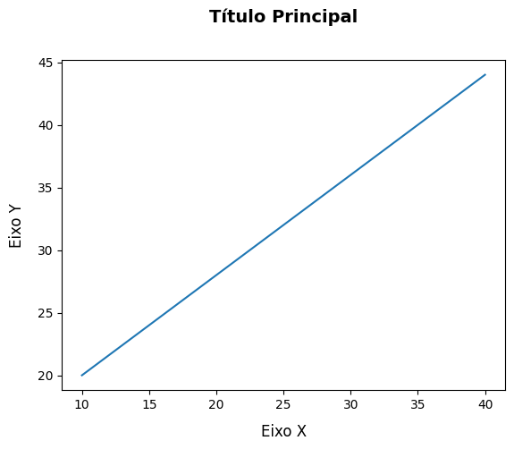

```python
# Exemplo de implementação

fig, ax = plt.subplots()
ax.plot(df["X"], df["Y"])
ax.set_title("Título Principal", fontsize=14, fontweight='bold', loc='center', pad=30)
ax.set_xlabel("Eixo X", fontsize=12, labelpad=10)
ax.set_ylabel("Eixo Y", fontsize=12, labelpad=10)
plt.show()
```

### 📋 Legenda

- **Função**: Exibe uma legenda para os elementos gráficos (linhas, pontos, barras).
- **Código:** O texto exibido na legenda vem do parâmetro label usado na função de plotagem (ax.plot(), ax.scatter(), etc.).
- **Principais parâmetros**:
  - loc → posição da legenda ('upper right', 'upper left', 'lower left', 'lower right', 'center', etc.).
  - bbox_to_anchor → coordenadas para posicionamento manual. Você passa coordenadas relativas (entre 0 e 1) para dizer onde esse ponto vai estar.
  - fontsize → tamanho do texto.
  - title → título da legenda.
  - frameon → exibir ou não a caixa da legenda (True ou False).
  - facecolor, edgecolor, framealpha → personalização do fundo, borda e transparência

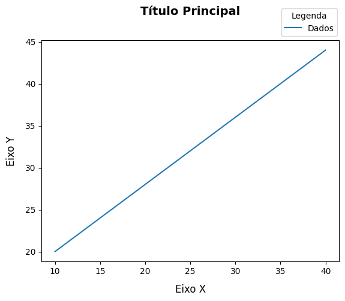

```python
# Exemplo de implementação

fig, ax = plt.subplots()
ax.plot(df["X"], df["Y"], label='Dados')
ax.set_title("Título Principal", fontsize=14, fontweight='bold', loc='center', pad=30)
ax.set_xlabel("Eixo X", fontsize=12, labelpad=10)
ax.set_ylabel("Eixo Y", fontsize=12, labelpad=10)
ax.legend(loc='lower center', bbox_to_anchor=(0.90, 1), fontsize=10, title="Legenda")
plt.show()
```

### 📌 Limites dos eixos

- **Função**: Define manualmente os limites do eixo X ou Y. Para focar em uma parte específica dos dados e para manter escala consistente entre múltiplos gráficos.
- **Código:** set_xlim() e set_ylim()
- **Principais parâmetros**:
  - (min, max) → valores numéricos para início e fim do eixo.

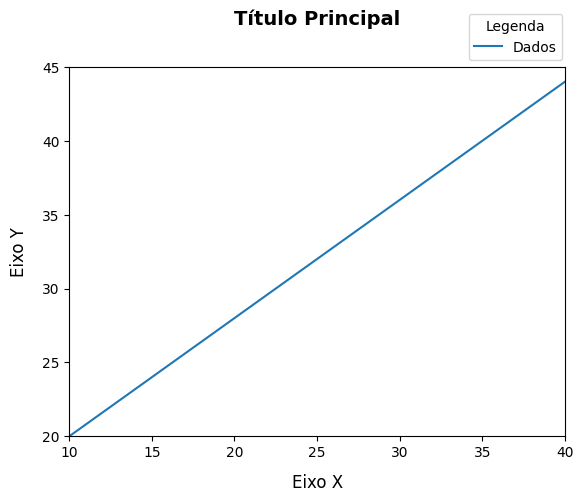

```python
# Exemplo de implementação

fig, ax = plt.subplots()
ax.plot(df["X"], df["Y"], label='Dados')
ax.set_title("Título Principal", fontsize=14, fontweight='bold', loc='center', pad=30)
ax.set_xlabel("Eixo X", fontsize=12, labelpad=10)
ax.set_ylabel("Eixo Y", fontsize=12, labelpad=10)
ax.legend(loc='lower center', bbox_to_anchor=(0.90, 1), fontsize=10, title="Legenda")
ax.set_xlim(10, 40)  # Eixo X de 10 a 40
ax.set_ylim(20, 45)  # Eixo Y de 20 a 45
plt.show()
```

### 📌 Marcações dos eixos

- **Função**: Personaliza a aparência e o comportamento dos ticks (marcas nos eixos) e seus rótulos.
- **Código:** tick_params()
- **Principais parâmetros**:
  - axis → 'x', 'y' ou 'both'.
  - rotation → rotação do texto do rótulo.
  - labelsize → tamanho da fonte.
  - length → comprimento da marca.
  - width → espessura da marca.
  - colors → cor dos rótulos e ticks.

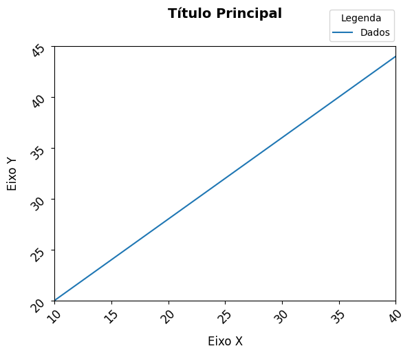

```python
# Exemplo de implementação

fig, ax = plt.subplots()
ax.plot(df["X"], df["Y"], label='Dados')
ax.set_title("Título Principal", fontsize=14, fontweight='bold', loc='center', pad=30)
ax.set_xlabel("Eixo X", fontsize=12, labelpad=10)
ax.set_ylabel("Eixo Y", fontsize=12, labelpad=10)
ax.legend(loc='lower center', bbox_to_anchor=(0.90, 1), fontsize=10, title="Legenda")
ax.set_xlim(10, 40)  # Eixo X de 10 a 40
ax.set_ylim(20, 45)  # Eixo Y de 20 a 45
ax.tick_params(axis='both', rotation=45, labelsize=12)  # Rotaciona rótulos do eixo X em 45°
plt.show()
```

### 📌 Escalas dos eixos

- **Função**: Por padrão, os eixos de um gráfico no Matplotlib usam escala linear, ou seja, os valores aumentam de forma uniforme.
- **Código:** set_xscale() e set_yscale()
- **Principais parâmetros**: tipo pode ser:
  - 'linear' → padrão, espaçamento uniforme.
  - 'log' → escala logarítmica (base 10 por padrão).
  - 'symlog' → logarítmica simétrica (aceita valores negativos próximos de zero).
  - 'logit' → escala logística (para proporções entre 0 e 1).

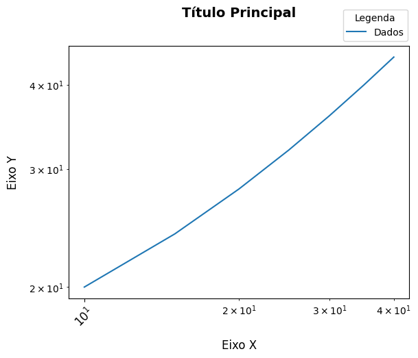

```python
# Exemplo de implementação

fig, ax = plt.subplots()
ax.plot(df["X"], df["Y"], label='Dados')
ax.set_title("Título Principal", fontsize=14, fontweight='bold', loc='center', pad=30)
ax.set_xlabel("Eixo X", fontsize=12, labelpad=10)
ax.set_ylabel("Eixo Y", fontsize=12, labelpad=10)
ax.legend(loc='lower center', bbox_to_anchor=(0.90, 1), fontsize=10, title="Legenda")
ax.set_xscale('log')
ax.set_yscale('log')
ax.tick_params(axis='both', rotation=45, labelsize=12)  # Rotaciona rótulos do eixo X em 45°
plt.show()
```

### 🎯 Tamanho da figura

- **Função**: Define o tamanho da figura em polegadas (largura, altura).
- **Código:** plt.figure(figsize=(largura, altura)) ou diretamente em plt.subplots(figsize=(largura, altura))

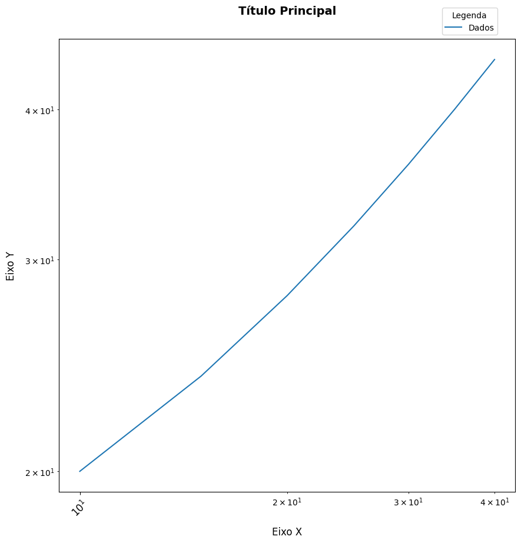

```python
# Exemplo de implementação

fig, ax = plt.subplots(figsize=(10, 10))
ax.plot(df["X"], df["Y"], label='Dados')
ax.set_title("Título Principal", fontsize=14, fontweight='bold', loc='center', pad=30)
ax.set_xlabel("Eixo X", fontsize=12, labelpad=10)
ax.set_ylabel("Eixo Y", fontsize=12, labelpad=10)
ax.legend(loc='lower center', bbox_to_anchor=(0.90, 1), fontsize=10, title="Legenda")
ax.set_xscale('log')
ax.set_yscale('log')
ax.tick_params(axis='both', rotation=45, labelsize=12)  # Rotaciona rótulos do eixo X em 45°
plt.show()
```

### 🔧 Subgráficos

- **Função**: "sub-plotagem", ou seja, um gráfico dentro de uma grade de gráficos na mesma figura. Muito útil para comparar diferentes visualizações lado a lado.
- **Código:** fig, axs = plt.subplots(nrows, ncols, figsize=(largura, altura))
- **Principais parâmetros**:
  - nrows → número de linhas.
  - ncols → número de colunas.
  - axs → objeto ou lista de objetos dos eixos criados.

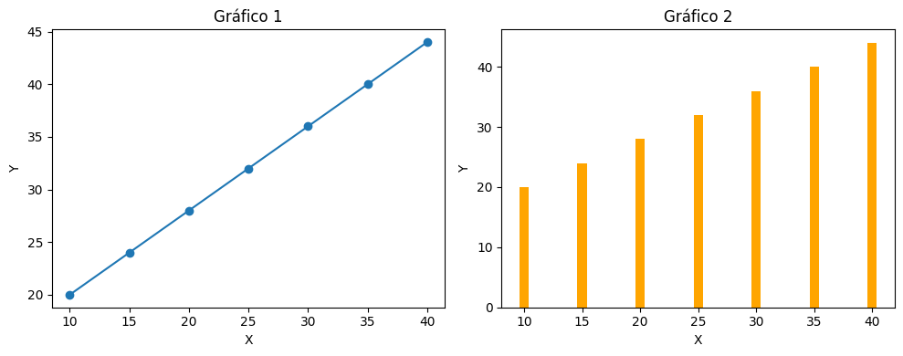

```python
# Exemplo de implementação

fig, axs = plt.subplots(1, 2, figsize=(10, 4))  # 1 linha, 2 colunas

# Primeiro gráfico
axs[0].plot(df["X"], df["Y"], marker='o')
axs[0].set_title("Gráfico 1")
axs[0].set_xlabel("X")
axs[0].set_ylabel("Y")

# Segundo gráfico
axs[1].bar(df["X"], df["Y"], color='orange')
axs[1].set_title("Gráfico 2")
axs[1].set_xlabel("X")
axs[1].set_ylabel("Y")

plt.tight_layout() # ajustando espaços entre subplots
plt.show()
```

### 📊 Linhas de grade

- **Função**: Adiciona uma grade ao gráfico para facilitar a leitura dos valores.
- **Código:** grid()
- **Principais parâmetros**:
  - True ou False → ativa/desativa a grade.
  - axis → 'x', 'y' ou 'both'.
  - linestyle → estilo da linha ('--', '-', ':').
  - color → cor da grade.
  - alpha → transparência.

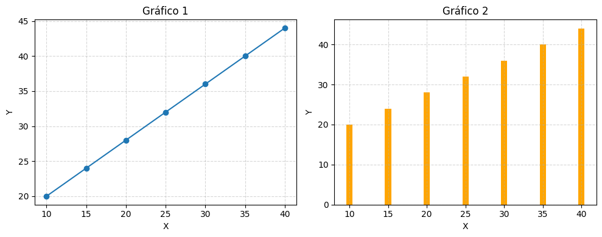

```python
# Exemplo de implementação

fig, axs = plt.subplots(1, 2, figsize=(10, 4))  # 1 linha, 2 colunas

# Primeiro gráfico
axs[0].plot(df["X"], df["Y"], marker='o')
axs[0].set_title("Gráfico 1")
axs[0].set_xlabel("X")
axs[0].set_ylabel("Y")
axs[0].grid(True, linestyle='--', alpha=0.5)

# Segundo gráfico
axs[1].bar(df["X"], df["Y"], color='orange')
axs[1].set_title("Gráfico 2")
axs[1].set_xlabel("X")
axs[1].set_ylabel("Y")
axs[1].grid(True, linestyle='--', alpha=0.5)

plt.tight_layout() # ajustando espaços entre subplots
plt.show()
```

### 📝Anotações

- **Função**: Adiciona texto e setas para destacar pontos específicos no gráfico.
- **Código:** annotate()
- **Principais parâmetros**:
  - text → texto a ser exibido.
  - xy → coordenada do ponto destacado.
  - xytext → coordenada onde o texto ficará.
  - arrowprops → dicionário com propriedades da seta (cor, estilo).

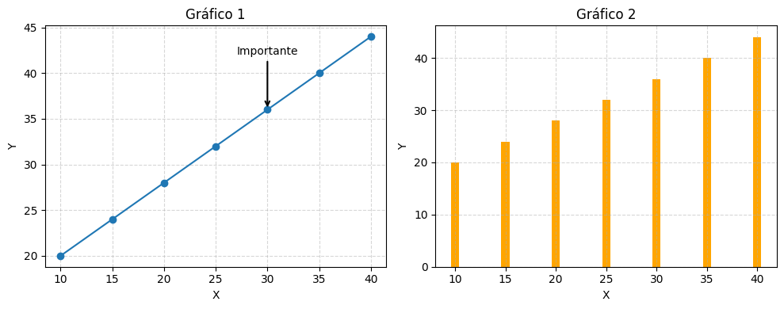

```python
# Exemplo de implementação

fig, axs = plt.subplots(1, 2, figsize=(10, 4))  # 1 linha, 2 colunas

# Primeiro gráfico
axs[0].plot(df["X"], df["Y"], marker='o')
axs[0].set_title("Gráfico 1")
axs[0].set_xlabel("X")
axs[0].set_ylabel("Y")
axs[0].grid(True, linestyle='--', alpha=0.5)

# Anotação com seta vindo de cima
axs[0].annotate(
    "Importante", # Texto exibido no gráfico
    xy=(30, 36),  # Coordenadas do ponto alvo
    xytext=(30, 42), # Coordenadas onde o texto será colocado
    ha='center', # Alinhamento horizontal do texto
    arrowprops=dict(  # Propriedades da seta
        facecolor='black',  # Cor de preenchimento da seta
        arrowstyle='->',    # Estilo da seta (seta simples)
        lw=1.5    # Espessura da linha da seta
    )
)

# Segundo gráfico
axs[1].bar(df["X"], df["Y"], color='orange')
axs[1].set_title("Gráfico 2")
axs[1].set_xlabel("X")
axs[1].set_ylabel("Y")
axs[1].grid(True, linestyle='--', alpha=0.5)

plt.tight_layout() # ajustando espaços entre subplots
plt.show()
```

### 📝Linha de referência

- **Função**: Desenha linhas de referência horizontal (axhline) ou vertical (axvline).
- **Código:** axhline() / axvline()
- **Principais parâmetros**:
  - y ou x → posição da linha.
  - color → cor da linha.
  - linestyle → estilo da linha.
  - lw → espessura.

[figure not shown]

```python
# Exemplo de implementação

fig, axs = plt.subplots(1, 2, figsize=(10, 4))  # 1 linha, 2 colunas

# Primeiro gráfico
axs[0].plot(df["X"], df["Y"], marker='o')
axs[0].set_title("Gráfico 1")
axs[0].set_xlabel("X")
axs[0].set_ylabel("Y")
axs[0].grid(True, linestyle='--', alpha=0.5)

# Anotação com seta vindo de cima
axs[0].annotate(
    "Importante", # Texto exibido no gráfico
    xy=(30, 36),  # Coordenadas do ponto alvo
    xytext=(30, 42), # Coordenadas onde o texto será colocado
    ha='center', # Alinhamento horizontal do texto. Pode ser: 'center' → centraliza, 'left' → alinha à esquerda, 'right' → alinha à direita.
    arrowprops=dict(  # Propriedades da seta
        facecolor='black',  # Cor de preenchimento da seta
        arrowstyle='->',    # Estilo da seta. Poder ser: aqui é seta simples, mas pode ser '-|>', '<->', etc.
        lw=1.5,    # Espessura da linha da seta
        linestyle='--'  # Estilo da linha da seta. Pode ser: '-', '--', '-.', ':'
    )
)

# Linhas de referência
axs[0].axhline(y=30, color='red', linestyle=':')
axs[0].axvline(x=25, color='blue', linestyle='--')

# Segundo gráfico
axs[1].bar(df["X"], df["Y"], color='orange')
axs[1].set_title("Gráfico 2")
axs[1].set_xlabel("X")
axs[1].set_ylabel("Y")
axs[1].grid(True, linestyle='--', alpha=0.5)

plt.tight_layout() # ajustando espaços entre subplots
plt.show()
```

### 📝 Destaque de área

- **Função**: Destaca uma área horizontal (axhspan) ou vertical (axvspan) com um retângulo sombreado.
- **Código:** axhspan() / axvspan()
- **Principais parâmetros**:
  - Início e fim (no eixo correspondente).
  - color → cor de preenchimento.
  - alpha → transparência.

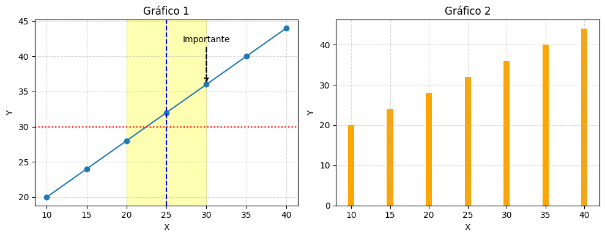

```python
# Exemplo de implementação

fig, axs = plt.subplots(1, 2, figsize=(10, 4))  # 1 linha, 2 colunas

# Primeiro gráfico
axs[0].plot(df["X"], df["Y"], marker='o')
axs[0].set_title("Gráfico 1")
axs[0].set_xlabel("X")
axs[0].set_ylabel("Y")
axs[0].grid(True, linestyle='--', alpha=0.5)

# Anotação com seta vindo de cima
axs[0].annotate(
    "Importante", # Texto exibido no gráfico
    xy=(30, 36),  # Coordenadas do ponto alvo
    xytext=(30, 42), # Coordenadas onde o texto será colocado
    ha='center', # Alinhamento horizontal do texto. Pode ser: 'center' → centraliza, 'left' → alinha à esquerda, 'right' → alinha à direita.
    arrowprops=dict(  # Propriedades da seta
        facecolor='black',  # Cor de preenchimento da seta
        arrowstyle='->',    # Estilo da seta. Poder ser: aqui é seta simples, mas pode ser '-|>', '<->', etc.
        lw=1.5,    # Espessura da linha da seta
        linestyle='--'  # Estilo da linha da seta. Pode ser: '-', '--', '-.', ':'
    )
)

# Linhas de referência
axs[0].axhline(y=30, color='red', linestyle=':')
axs[0].axvline(x=25, color='blue', linestyle='--')

# Áreas sombreadas
axs[0].axvspan(20, 30, color='yellow', alpha=0.3)

# Segundo gráfico
axs[1].bar(df["X"], df["Y"], color='orange')
axs[1].set_title("Gráfico 2")
axs[1].set_xlabel("X")
axs[1].set_ylabel("Y")
axs[1].grid(True, linestyle='--', alpha=0.5)

plt.tight_layout() # ajustando espaços entre subplots
plt.show()
```

### #️⃣ Rótulo de valores

- **Função**: Adiciona valores diretamente sobre os pontos ou barras do gráfico para facilitar a interpretação visual.
- **Principais parâmetros**:
  - padding → distância entre o texto e a barra (bar_label).
  - fontsize → tamanho da fonte.
  - color → cor do texto.
  - ha → alinhamento horizontal ('center', 'left', 'right').
  - va → alinhamento vertical ('bottom', 'top').
  - xytext → deslocamento do texto (em annotate).
- **Código:**

| Tipo de gráfico | Melhor forma de colocar rótulos |
| --- | --- |
| Barras (`bar`, `barh`) | `ax.bar_label()` |
| Linha (`plot`) | `ax.text()` ou `ax.annotate()` |
| Dispersão (`scatter`) | `ax.text()` ou `ax.annotate()` |
| Pizza (`pie`) | `autopct` no `pie()` |

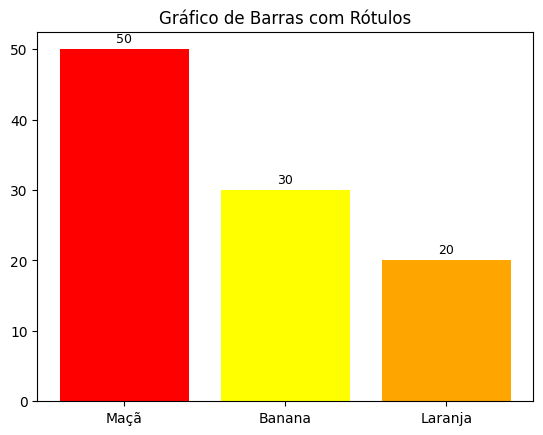

```python
# ===== 1. Barras =====
fig, ax = plt.subplots()
frutas = ['Maçã', 'Banana', 'Laranja']
valores = [50, 30, 20]
barras = ax.bar(frutas, valores, color=['red', 'yellow', 'orange'])
ax.bar_label(barras, padding=3, fontsize=9)
ax.set_title("Gráfico de Barras com Rótulos")
plt.show()
```

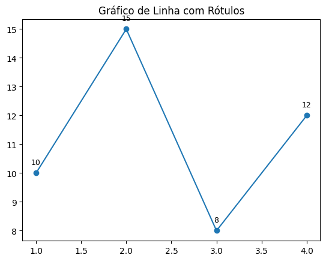

```python
# ===== 2. Linha =====
fig, ax = plt.subplots()
x = [1, 2, 3, 4]
y = [10, 15, 8, 12]
ax.plot(x, y, marker='o')
for xi, yi in zip(x, y):
    ax.text(xi, yi + 0.3, f"{yi}", ha='center', fontsize=9)
ax.set_title("Gráfico de Linha com Rótulos")
plt.show()
```

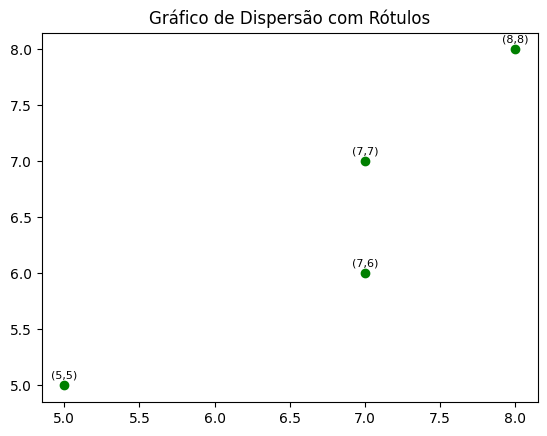

```python
# ===== 3. Dispersão =====
fig, ax = plt.subplots()
x = [5, 7, 8, 7]
y = [5, 7, 8, 6]
ax.scatter(x, y, color='green')
for xi, yi in zip(x, y):
    ax.annotate(f"({xi},{yi})", (xi, yi), textcoords="offset points", xytext=(0, 5), ha='center', fontsize=8)
ax.set_title("Gráfico de Dispersão com Rótulos")
plt.show()
```

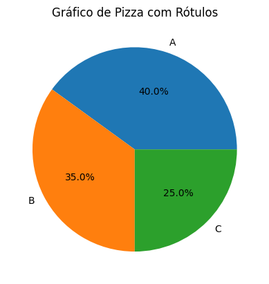

```python
# ===== 4. Pizza =====
fig, ax = plt.subplots()
tamanhos = [40, 35, 25]
rotulos = ['A', 'B', 'C']
ax.pie(tamanhos, labels=rotulos, autopct='%1.1f%%')
ax.set_title("Gráfico de Pizza com Rótulos")
plt.show()
```

## 🔚 Código final para customização

```python
def plot_exemplo_unico_linha(df):

    """
    Gera um gráfico de linha com:
    - Títulos e rótulos de eixos
    - Grid
    - Anotação com seta
    - Linhas de referência
    - Área sombreada
    - Rótulos de valores sobre os pontos

    Parâmetros:
    df (pd.DataFrame): DataFrame contendo as colunas 'X' e 'Y' para plotagem.
    """

    # ==========================================================================
    # 1. Criação da figura e dos eixos
    #    - plt.subplots() é a maneira recomendada de criar uma figura (a janela
    #      onde o gráfico é desenhado) e um conjunto de eixos (a área onde os
    #      dados são plotados). Cada eixo é um subplot dentro da figura.
    # ==========================================================================
    fig, ax = plt.subplots(figsize=(8, 5)) # figsize=(largura, altura) em polegadas

    # ==========================================================================
    # 2. Definição do tipo de gráfico (Gráfico de Linha)
    #    - ax.plot() é usado para desenhar gráficos de linha.
    # ==========================================================================
    ax.plot(df["X"], df["Y"],         # Dados para os eixos X e Y
            marker='o',             # Adiciona marcadores em forma de círculo nos pontos de dados
            label="Dados",          # Rótulo para esta série de dados, usado na legenda
            color='blue')           # Define a cor da linha como azul

    # ==========================================================================
    # 3. Definição dos títulos e rótulos dos eixos
    #    - set_title(): Define o título principal do gráfico.
    #    - set_xlabel(): Define o rótulo do eixo horizontal (X).
    #    - set_ylabel(): Define o rótulo do eixo vertical (Y).
    # ==========================================================================
    ax.set_title("Título Principal", # Texto do título
                 fontsize=14,       # Tamanho da fonte do título
                 fontweight='bold', # Peso da fonte (ex: 'bold', 'normal')
                 loc='center',      # Alinhamento do título ('center', 'left', 'right')
                 pad=30)            # Espaçamento entre o título e o gráfico
    ax.set_xlabel("Eixo X",             # Texto do rótulo do eixo X
                  fontsize=12,      # Tamanho da fonte do rótulo X
                  labelpad=10)      # Espaçamento entre o rótulo X e o eixo
    ax.set_ylabel("Eixo Y",             # Texto do rótulo do eixo Y
                  fontsize=12,      # Tamanho da fonte do rótulo Y
                  labelpad=10)      # Espaçamento entre o rótulo Y e o eixo

    # ==========================================================================
    # 4. Definição da legenda
    #    - ax.legend(): Exibe a legenda do gráfico. Os rótulos vêm do parâmetro
    #      'label' das funções de plotagem (ex: ax.plot).
    # ==========================================================================
    ax.legend(loc='lower center',       # Posição da legenda ('upper right', 'lower left', etc.)
              bbox_to_anchor=(0.90, 1), # Coordenadas (x, y) para posicionamento manual da legenda
              fontsize=10,            # Tamanho da fonte dos itens da legenda
              title="Legenda")        # Título da legenda

    # ==========================================================================
    # 5. Definição do limite dos eixos
    #    - ax.set_xlim(): Define os limites mínimo e máximo para o eixo X.
    #    - ax.set_ylim(): Define os limites mínimo e máximo para o eixo Y.
    # ==========================================================================
    ax.set_xlim(10, 40) # Limite do eixo X de 10 a 40
    ax.set_ylim(20, 45) # Limite do eixo Y de 20 a 45

    # ==========================================================================
    # 6. Definição das marcações (ticks) dos eixos
    #    - ax.tick_params(): Personaliza a aparência e o comportamento dos ticks
    #      e seus rótulos.
    # ==========================================================================
    ax.tick_params(axis='both',       # Aplica as configurações a ambos os eixos (x e y)
                    rotation=0,        # Rotação dos rótulos dos ticks em graus
                    labelsize=12)      # Tamanho da fonte dos rótulos dos ticks

    # ==========================================================================
    # 7. Definição das linhas de grade
    #    - ax.grid(): Adiciona linhas de grade ao gráfico para facilitar a leitura.
    # ==========================================================================
    ax.grid(True,                     # Ativa as linhas de grade
            linestyle='--',          # Estilo da linha (ex: '-', '--', ':', '-.')
            alpha=0.5)                # Transparência da linha de grade (0.0 a 1.0)

    # ==========================================================================
    # 8. Definição de linhas de referência
    #    - ax.axhline(): Desenha uma linha horizontal no gráfico.
    #    - ax.axvline(): Desenha uma linha vertical no gráfico.
    # ==========================================================================
    ax.axhline(y=32,                  # Posição da linha horizontal no eixo Y
               color='red',           # Cor da linha
               linestyle=':',         # Estilo da linha
               linewidth=1)           # Espessura da linha
    ax.axvline(x=25,                  # Posição da linha vertical no eixo X
               color='blue',          # Cor da linha
               linestyle='--',        # Estilo da linha
               linewidth=1)           # Espessura da linha

    # ==========================================================================
    # 9. Definição de rótulos de valores sobre os pontos
    #    - ax.text(): Adiciona texto em uma posição específica no gráfico.
    # ==========================================================================
    for x_val, y_val in zip(df["X"], df["Y"]): # Itera sobre cada ponto (X, Y)
        ax.text(x_val, y_val + 0.5,        # Posição (x, y) do texto (um pouco acima do ponto)
                f"{y_val}",                # Conteúdo do texto (valor de Y)
                ha='center',               # Alinhamento horizontal ('center', 'left', 'right')
                va='bottom',               # Alinhamento vertical ('bottom', 'top', 'center')
                fontsize=9,                # Tamanho da fonte do texto
                color='black')             # Cor do texto

    # ==========================================================================
    # 10. Definição de anotações (comentado por padrão, descomentar para usar)
    #    - ax.annotate(): Adiciona texto com uma seta para destacar um ponto.
    # ==========================================================================
    # ax.annotate(
    #     "Importante",                  # Texto da anotação
    #     xy=(30, 36),                   # Coordenadas do ponto alvo (onde a seta aponta)
    #     xytext=(30, 42),               # Coordenadas onde o texto da anotação será colocado
    #     ha='center',                   # Alinhamento horizontal do texto
    #     arrowprops=dict(               # Dicionário de propriedades da seta
    #         facecolor='black',         # Cor de preenchimento da seta
    #         arrowstyle='->',           # Estilo da seta (ex: '->', '-|>', '<->')
    #         lw=1.5,                    # Espessura da linha da seta
    #         linestyle='--'             # Estilo da linha da seta
    #     )
    # )

    # ==========================================================================
    # 11. Definição de área de destaque (sombreada)
    #    - ax.axvspan(): Destaca uma área vertical com um retângulo sombreado.
    #    - ax.axhspan(): Destaca uma área horizontal (não usada neste exemplo).
    # ==========================================================================
    ax.axvspan(20, 30,                  # Intervalo no eixo X para a área sombreada
               color='yellow',          # Cor de preenchimento da área
               alpha=0.3)               # Transparência da área

    # ==========================================================================
    # 12. Plotagem final do gráfico
    #    - plt.show(): Exibe o gráfico. É essencial chamar esta função para
    #      renderizar e mostrar o gráfico na saída.
    # ==========================================================================
    plt.show()
```

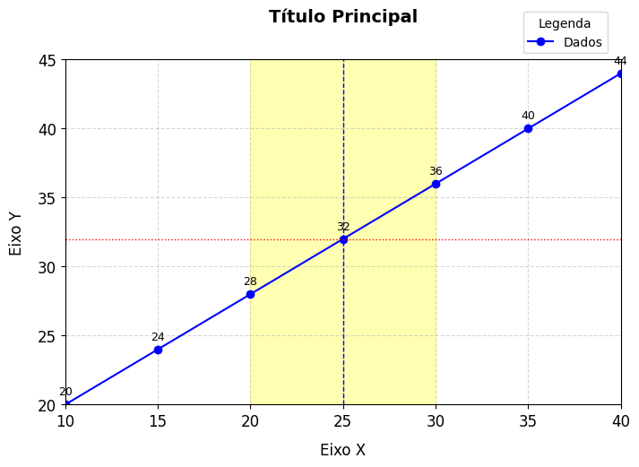

```python
plot_exemplo_unico_linha(df)
```

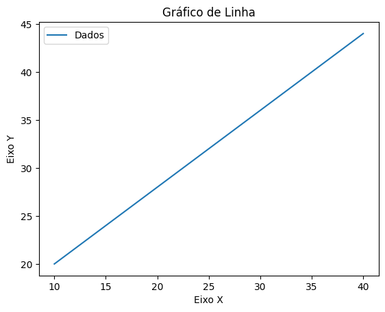

```python
# Exemplo de como extrair (salvar) o gráfico

# Recriando o gráfico para demonstração
fig, ax = plt.subplots()
ax.plot(df["X"], df["Y"], label='Dados')
ax.set_title("Gráfico de Linha")
ax.set_xlabel("Eixo X")
ax.set_ylabel("Eixo Y")
ax.legend()

# Salva o gráfico como um arquivo PNG
plt.savefig('meu_grafico_linha.png')

# Salva o gráfico como um arquivo PDF
plt.savefig('meu_grafico_linha.pdf')

plt.show()
```